# Manipulação de dados

José Felipe Custódia de Azevedo/ josefelipe0036@gmail.com

# Respostas:

**Observações: o trabalho foi realizado com software R e o relatório com o R Markdown, para reduzir o tamanho do arquivo, os gráficos gerados estarão junto com os códigos.**

## Questão 1

Na primeira questão foi ultilizado o método de remoção dos valores faltantes através da função *filter* junto com a função *is.na*, no qual, a combinação resulta em uma filtragem dos NA’s onde quando é usado o sinal de exclamação significa uma negação, ou seja, seleciona tudo menos a condição que foi colocada no filter. Poderia ter sido usado outro método em que consiste em substituir o valor ausente pela média da variável mas por ser mais prático usei o primeiro. Usei a variável *hf_rank* para remover todos os NA’s.

## Questão 2

Fiz a soma das variáveis e salvei como um valor, posteriormente foi usado a função *mutate* para “juntar” o total de medalhas com a base de dados.

## Questão 3

A quantidade de medalha de ouro foi organizada de forma decrescente para montar o ranking, foram usadas as funções *arrange*, *desc* e *head* para mostrar os 10 primeiros países que mais tinham medalhas de ouro, e também que mais tinham medalhas.

## Questão 4

Foi criado um novo dataset baseado no *Countries*, só que os dados foram agrupados pela região e criado uma coluna com a média de alfabetização por região, usando a função *summarise*.

## Questão 5

A questão 5 seguiu a mesma lógica da questão 3, só que foi usado a função *select* para facilitar na plotagem do gráfico.

## Questão 6

Foi usado a função *filter*, com as condições de que o ano seja 2018.

## Questão 7

A função *filter* foi usada para selecionar o Brasil, para facilitar a visualização foi feito um gráfico de linha.

## Questão 8

Os dados foram agrupados pela região, logo em seguida foi calculada a média da região.

## Questão 9

Não, pois foi calculado o coeficiente de correlação, onde obteve -0.08, que significa que não a correlação é muito fraca, pois a correlação varia de -1 a 1, onde <0 é fraca.

## Questão 10

Foi usado a mesma lógica da 3, só que em vez das medalhas de ouro, foram as de bronze.

## Questão 11

Foi usado a função *scale* para escalonar algumas variáveis do banco de dados, foi necessário transformar em *numeric* uma coluna. Não foi salvo o escalonamento para não inferir nas questões posteriores, pois o escalonamento seria mais funcional para a criação de algum algoritmo de IA ou aprendizado de máquina.

## Questão 13

Sim, foi observado uma correlação de 0.2, tem uma relação relativamente boa, pois, levando em consideração que agricultura costuma ser um trabalho em coletivo que diversas pessoas buscam um objetivo em comum, portanto o teórico de movimentos sociais Tilly (1981, p. 17), há ação coletiva em “[…] todas as ocasiões em que grupos de pessoas mobilizam recursos, incluindo seus próprios esforços, para alcançar objetivos comuns”.

## Questão 15

Bem houve um impacto negativo, pois se observamos os dados do ano de 2013 a 2018, pois de 2013 até 2015 os Estados Unidos saiu da posição 17° para 13°, onde em 2016 o EUA foia para a 14°, ou seja, caiu uma posição.

## Questão 16

Sim, pois o valor foi de 0,46. Pois, quando o tamanho amostral é grande, ele otimiza o resultado, pois aumenta a probabilidade encontrar um atleta de ponta. Para realizar essa questão tive que juntar dois bancos de dados *countries* e *medals_olympics*, foi usado a função *inner_join* para juntar os dados,onde facilitou a achar a correlação.

## Questão 17

Para facilitar, primeiramente foi removido a variável *GDP per capita* para não haver “erro”, apois isso todos os 4 bancos de dados foram unidos, onde o Brasil deveria melhorar a *GDP per capita*, o índice de alfabetizção e a liberdade de escolha, pois todas as variáveis foram escolhidas atráves da correlação.

## Questão 18

Países litorâneos com base na correlação investem mais em indústria do que na agricultura, pois um dos possíveis motivos é que por ser litorâneo, a indústria é mais movimentada, por exemplo se torna mais barato o transporte de produtos industriais, etc.

## Questão 19

Foi selecionado *Country* e *Region* do banco de dados Countries e depois foi colocado junto com medals_olympics, onde foi feita a soma das medalhas por região, onde a região que mais obteve medalha foi a Europa Ocidental.

# Códigos e imagens

```r
library(readxl)#carregando as bibliotecas
library(tidyverse)
countries <- read_excel("~/Área de Trabalho/countries.xlsx")
human_freedom<-read_xlsx("~/Área de Trabalho/human_freedom.xlsx")#lendo os dados
medals_olympics<- read_xlsx("~/Área de Trabalho/medals_olympics.xlsx")
hapiness_report<-read_xlsx("~/Área de Trabalho/hapiness_report.xlsx")
```

## Questão1

```r
summary(human_freedom)
```

```
##       year        ISO_code          countries            region
##  Min.   :2008   Length:572         Length:572         Length:572
##  1st Qu.:2010   Class :character   Class :character   Class :character
##  Median :2013   Mode  :character   Mode  :character   Mode  :character
##  Mean   :2013
##  3rd Qu.:2016
##  Max.   :2018
##
##     hf_score        hf_rank          pf_score        pf_rank
##  Min.   :3.850   Min.   :  1.00   Min.   :3.600   Min.   :  1.00
##  1st Qu.:6.890   1st Qu.: 15.00   1st Qu.:7.027   1st Qu.: 17.00
##  Median :8.015   Median : 37.00   Median :8.530   Median : 35.50
##  Mean   :7.587   Mean   : 52.41   Mean   :7.914   Mean   : 53.09
##  3rd Qu.:8.450   3rd Qu.: 84.00   3rd Qu.:9.047   3rd Qu.: 86.75
##  Max.   :8.990   Max.   :161.00   Max.   :9.590   Max.   :159.00
##  NA's   :10      NA's   :10       NA's   :10      NA's   :10
##     ef_score        ef_rank       pf_ss_homicide  womens_freedom
##  Min.   :2.720   Min.   :  1.00   Min.   :0.000   Length:572
##  1st Qu.:6.880   1st Qu.: 20.25   1st Qu.:8.300   Class :character
##  Median :7.520   Median : 43.00   Median :9.500   Mode  :character
##  Mean   :7.255   Mean   : 54.72   Mean   :8.305
##  3rd Qu.:7.808   3rd Qu.: 81.00   3rd Qu.:9.700
##  Max.   :8.970   Max.   :162.00   Max.   :9.900
##  NA's   :10      NA's   :10       NA's   :10
```

```r
##limpando humam_freedom Método1
#human_freedom$hf_score= ifelse(is.na(human_freedom$hf_score),
                               #mean(human_freedom$hf_score, na.rm = T),
                               #human_freedom$hf_score)
#human_freedom$hf_score==0.0 #verificando se há alguma observação zerada
#human_freedom$hf_score<0 #verificando se há alguam obs menor do que zero

##limpando humam_freedom pelo metodo2, usando como referência hf_rank
human_freedom<-filter(human_freedom, !is.na(human_freedom$hf_rank))
#is.na(human_freedom) testando se há NA
```

## Questão 2

```r
Total<-medals_olympics$`Gold Medal`+medals_olympics$`Silver Medal`+medals_olympics$`Bronze Medal`
medals_olympics=mutate(medals_olympics,Total)
head(medals_olympics)
```

```
## # A tibble: 6 × 5
##   Country       `Gold Medal` `Silver Medal` `Bronze Medal` Total
##   <chr>                <dbl>          <dbl>          <dbl> <dbl>
## 1 unitedstates            39             41             33   113
## 2 china                   38             32             18    88
## 3 japan                   27             14             17    58
## 4 unitedkingdom           22             21             22    65
## 5 russia                  20             28             23    71
## 6 australia               17              7             22    46
```

## Questão 3

```r
head(top<-head(arrange(medals_olympics,
                       desc('Gold Medal')),10))#lista dos 10 maiores medalhista de ouro.
```

```
## # A tibble: 6 × 5
##   Country       `Gold Medal` `Silver Medal` `Bronze Medal` Total
##   <chr>                <dbl>          <dbl>          <dbl> <dbl>
## 1 unitedstates            39             41             33   113
## 2 china                   38             32             18    88
## 3 japan                   27             14             17    58
## 4 unitedkingdom           22             21             22    65
## 5 russia                  20             28             23    71
## 6 australia               17              7             22    46
```

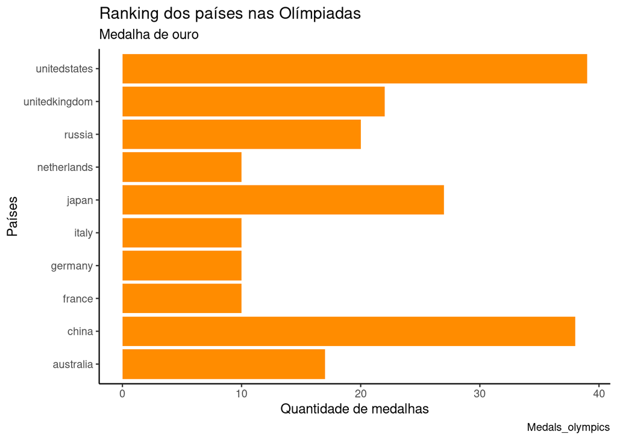

```r
ggplot(top) +
  aes(x = Country, weight = `Gold Medal`) +
  geom_bar(fill = "#FF8C00") +
  labs(
    x = "Países",
    y = "Quantidade de medalhas",
    title = "Ranking dos países nas Olímpiadas",
    subtitle = "Medalha de ouro",
    caption = "Medals_olympics"
  ) +
  coord_flip() +
  theme_classic()#gráfico de coluna dos 10 maiores medalhista de ouro.
```

```r
head(arrange(medals_olympics, desc(Total)),10)# maiore medalhistas pelo total.
```

```
## # A tibble: 10 × 5
##    Country       `Gold Medal` `Silver Medal` `Bronze Medal` Total
##    <chr>                <dbl>          <dbl>          <dbl> <dbl>
##  1 unitedstates            39             41             33   113
##  2 china                   38             32             18    88
##  3 russia                  20             28             23    71
##  4 unitedkingdom           22             21             22    65
##  5 japan                   27             14             17    58
##  6 australia               17              7             22    46
##  7 italy                   10             10             20    40
##  8 germany                 10             11             16    37
##  9 netherlands             10             12             14    36
## 10 france                  10             12             11    33
```

## Questão 4

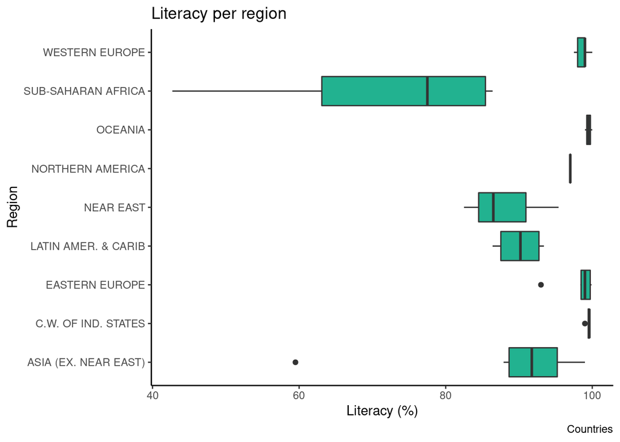

```r
ggplot(countries) +
  aes(x = Region, y = `Literacy (%)`) +
  geom_boxplot(shape = "circle", fill = "#22B290") +
  labs(title = "Literacy per region", caption = "Countries") +
  coord_flip()+
  theme_classic()#Boxplot para mostrar a variação
```

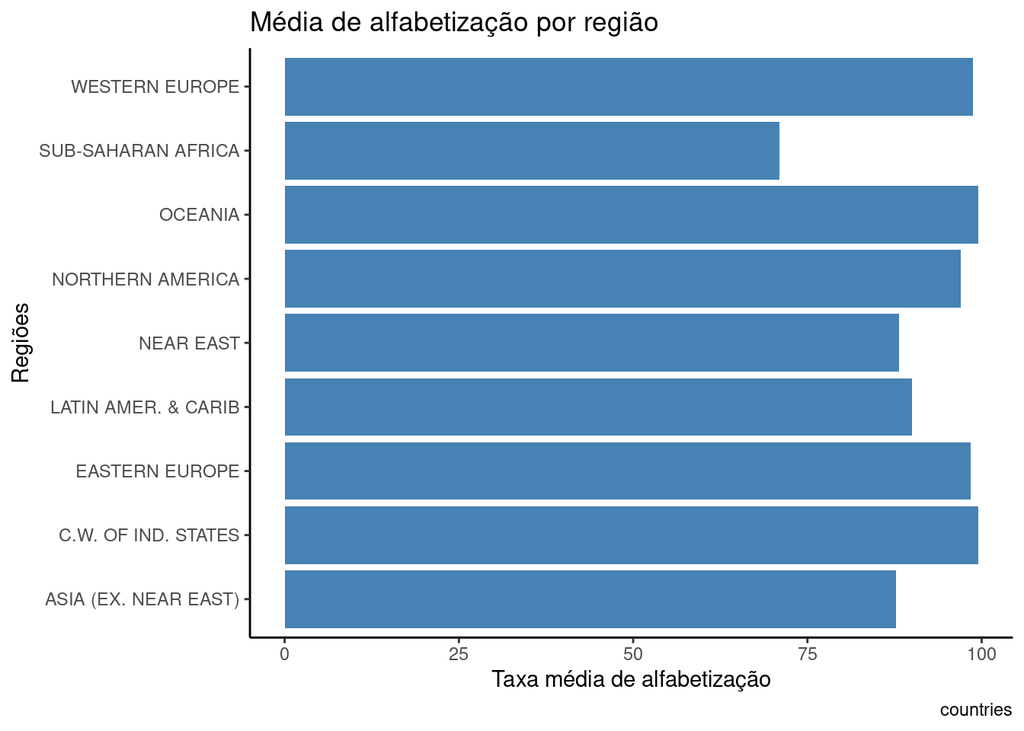

```r
region_literacy<-countries%>%
  group_by(Region)%>%
  summarise(mean_region = mean(`Literacy (%)`))


ggplot(region_literacy) +
  aes(x = Region, weight = mean_region) +
  geom_bar(fill = "#4682B4") +
  labs(
    x = "Regiões",
    y = "Taxa média de alfabetização",
    title = "Média de alfabetização por região",
    caption = "countries"
  ) +
  coord_flip() +
  theme_classic()# média de alfabetização por região
```

## Questão 5

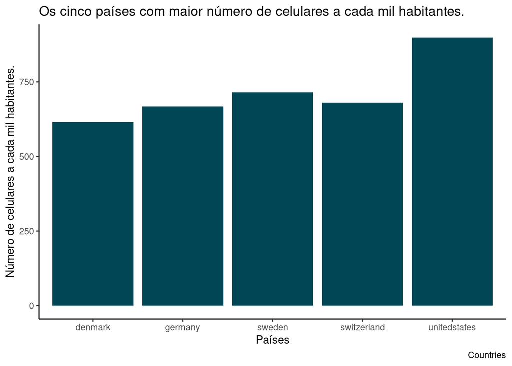

```r
phone_per1000<-head(arrange(countries,desc(`Phones (per 1000)`)),5)%>%
  select(Country, 'Phones (per 1000)')


ggplot(phone_per1000) +
  aes(x = Country, weight = `Phones (per 1000)`) +
  geom_bar(fill = "#014654") +
  labs(
    x = "Países",
    y = "Número de celulares a cada mil habitantes.",
    title = "Os cinco países com maior número de celulares a cada mil habitantes.",
    caption = "Countries"
  ) +
  theme_classic()# 5 países com mais numeros a cada 100 mil habitantes
```

## Questão 6

```r
human_freedom%>%
  filter(year == 2018)%>%
  head()
```

```
## # A tibble: 6 × 12
##    year ISO_code countr…¹ region hf_sc…² hf_rank pf_sc…³ pf_rank ef_sc…⁴ ef_rank
##   <dbl> <chr>    <chr>    <chr>    <dbl>   <dbl>   <dbl>   <dbl>   <dbl>   <dbl>
## 1  2018 AUS      austral… Ocean…    8.68       5    9.12      10    8.23       5
## 2  2018 AUT      austria  Weste…    8.45      15    9.09      15    7.8       26
## 3  2018 BLR      belarus  Easte…    6.67      99    6.99      85    6.35     114
## 4  2018 BEL      belgium  Weste…    8.28      25    8.99      17    7.56      49
## 5  2018 BRA      brazil   Latin…    6.83      88    7.1       78    6.56     105
## 6  2018 BGR      bulgaria Easte…    7.93      37    8.11      41    7.74      32
## # … with 2 more variables: pf_ss_homicide <dbl>, womens_freedom <chr>, and
## #   abbreviated variable names ¹countries, ²hf_score, ³pf_score, ⁴ef_score
```

## Questão 7

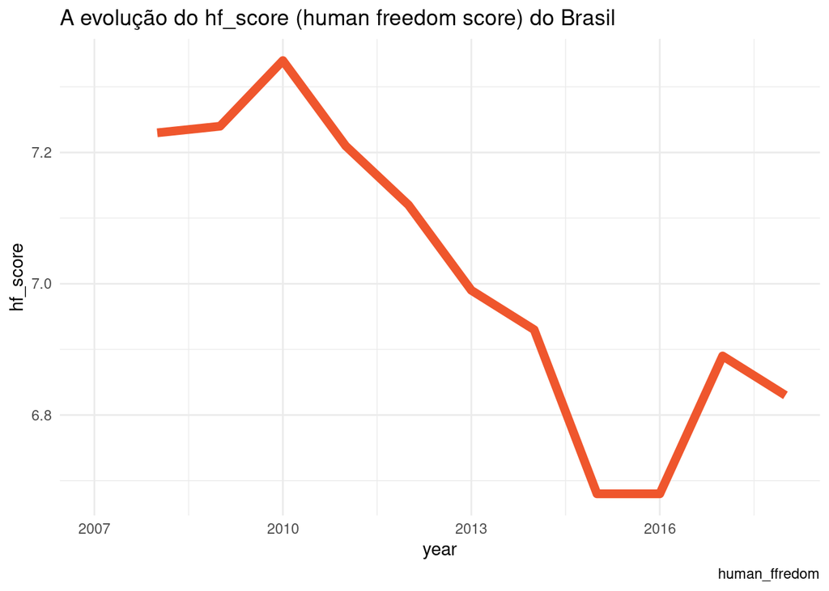

```r
(grafico_brasil<-human_freedom%>%
  filter(countries=="brazil")%>%
  select(year, countries, hf_score)%>%
  ggplot() +
  aes(x = year, y = hf_score) +
  geom_line(size = 2.5, colour = "#EF562D") +
  labs(title = "A evolução do hf_score (human freedom score) do Brasil",
       caption = "human_ffredom") +
  theme_minimal() +
  xlim(2007L, 2018L)) #gráfico de linha da evolução de hf_score
```

## Questão 8

```r
region_pop<-countries%>%
  group_by(Region)%>%
  summarise(pop_region = mean(Population))
head(arrange(region_pop, desc(pop_region)),1)#maior média populacional por região
```

```
## # A tibble: 1 × 2
##   Region               pop_region
##   <chr>                     <dbl>
## 1 ASIA (EX. NEAR EAST) 482457804.
```

## Questão 9

```r
cor(countries$Population, countries$`Net migration`) # Calculando correlação
```

```
## [1] -0.08053571
```

## Questão 10

```r
(bronze<-head(
  arrange(medals_olympics,
          desc(medals_olympics$`Bronze Medal`)),10))
```

```
## # A tibble: 10 × 5
##    Country       `Gold Medal` `Silver Medal` `Bronze Medal` Total
##    <chr>                <dbl>          <dbl>          <dbl> <dbl>
##  1 unitedstates            39             41             33   113
##  2 russia                  20             28             23    71
##  3 unitedkingdom           22             21             22    65
##  4 australia               17              7             22    46
##  5 italy                   10             10             20    40
##  6 china                   38             32             18    88
##  7 japan                   27             14             17    58
##  8 germany                 10             11             16    37
##  9 netherlands             10             12             14    36
## 10 ukraine                  1              6             12    19
```

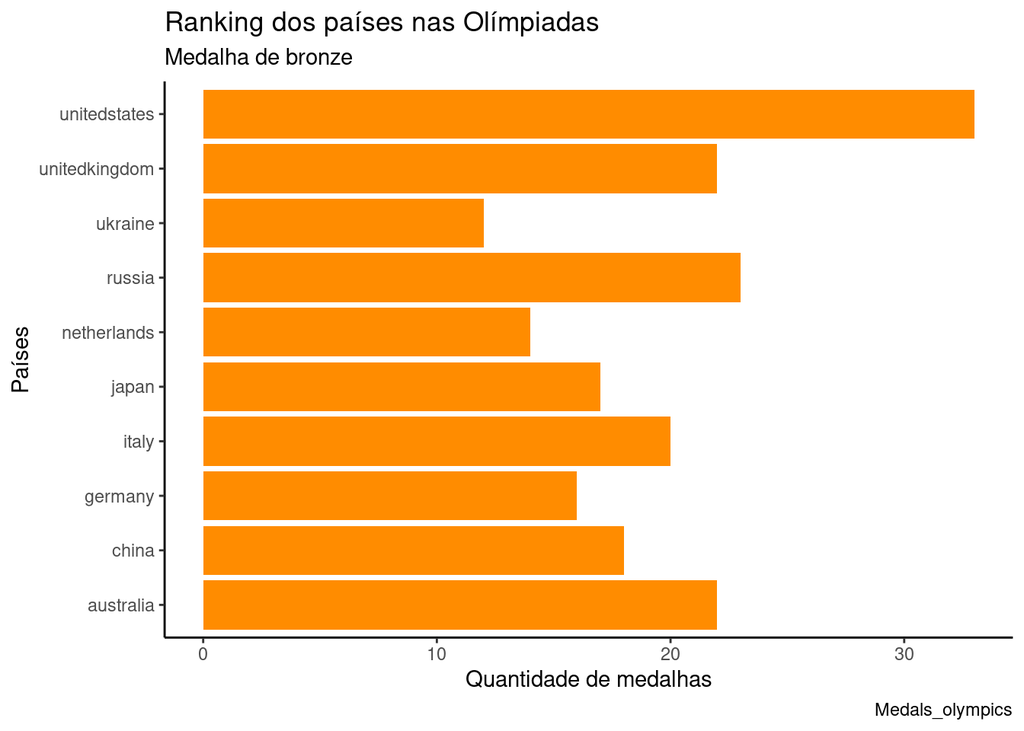

```r
ggplot(bronze) +
  aes(x = Country, weight = `Bronze Medal`) +
  geom_bar(fill = "#FF8C00") +
  labs(
    x = "Países",
    y = "Quantidade de medalhas",
    title = "Ranking dos países nas Olímpiadas",
    subtitle = "Medalha de bronze",
    caption = "Medals_olympics"
  ) +
  coord_flip() +
  theme_classic()# Maiores medalhistas de bronze
```

## Questão 11

```r
medal_scale <-(scale(medals_olympics[,2:4]))
countries_scale <-(scale(countries[,3:20]))
human_freedom$womens_freedom = as.numeric(human_freedom$womens_freedom)
# Transformando womens_freedom em número para o escalonamento
human_scale <-(scale(human_freedom[,5:12]))
hapiness_scale <-(scale(hapiness_report[,3:9]))

head(medal_scale)
```

```
##      Gold Medal Silver Medal Bronze Medal
## [1,]   3.825745    4.3043889     3.555985
## [2,]   3.709475    3.2005785     1.529931
## [3,]   2.430500    0.9929577     1.394860
## [4,]   1.849147    1.8514769     2.070212
## [5,]   1.616606    2.7099961     2.205282
## [6,]   1.267795    0.1344384     2.070212
```

```r
head(countries_scale)
```

```
##      Population Area (sq. mi.) Pop. Density (per sq. mi.)
## [1,] -0.3007776      1.6684799                 -1.0185443
## [2,] -0.3498754     -0.4429871                 -0.2716430
## [3,] -0.3413334     -0.4086253                 -0.6494133
## [4,] -0.3409834     -0.4578010                  1.6313452
## [5,]  0.3817822      1.8976273                 -0.8653942
## [6,] -0.3531599     -0.4354776                 -0.5158978
##      Coastline (coast/area ratio) Net migration
## [1,]                   -0.5374467    0.86863024
## [2,]                   -0.6241719    0.29386680
## [3,]                   -0.6241719    0.45062046
## [4,]                   -0.5680556    0.07034768
## [5,]                   -0.6012152   -0.29541087
## [6,]                   -0.5425481   -1.61620563
##      Infant mortality (per 1000 births) GDP ($ per capita) Literacy (%)
```

[output cut: 20 more lines]

```r
head(human_scale)
```

```
##       hf_score   hf_rank  pf_score    pf_rank  ef_score   ef_rank
## [1,] 0.9982411 -1.057913 0.8670908 -0.9531218 1.0299127 -1.162046
## [2,] 0.9799749 -1.035600 0.8742811 -0.9310038 0.9770919 -1.115305
## [3,] 0.9525755 -1.035600 0.8527103 -0.9310038 0.9559635 -1.091934
## [4,] 0.9434424 -1.035600 0.8742811 -0.9310038 0.8925785 -1.021822
## [5,] 1.0073743 -1.035600 0.9677544 -0.9973579 0.9031427 -1.045193
## [6,] 0.9343092 -1.013287 0.9174226 -0.9973579 0.8080651 -1.068563
##      pf_ss_homicide womens_freedom
## [1,]      0.4832158      0.4935293
## [2,]      0.5205344      0.4935293
## [3,]      0.4832158      0.4935293
## [4,]      0.4832158      0.4935293
## [5,]      0.4832158      0.4935293
## [6,]      0.4832158      0.4935293
```

```r
head(hapiness_scale)
```

```
##         Score GDP per capita Social support Healthy life expectancy
## [1,] 1.476458      0.7962330      0.9863248               0.7438249
## [2,] 1.432501      1.1570603      1.0308515               0.9371730
## [3,] 1.369433      0.8409068      0.7340067               0.7619512
## [4,] 1.361788      1.0333481      0.7537964               1.0821842
## [5,] 1.230873      0.8099788      0.5608472               0.8223726
## [6,] 1.196472      0.5213169      0.9071662               0.9250888
##      Freedom to make life choices Generosity Perceptions of corruption
## [1,]                     1.261969  0.6337989                  2.282675
## [2,]                     1.343524  0.8113342                  1.703251
## [3,]                     1.002477  1.2878762                  1.342161
## [4,]                     1.113688  0.7365825                  1.720046
## [5,]                     1.128516  0.7739583                  1.971970
## [6,]                     1.210071  1.3626279                  2.030752
```

## Questão 12

```r
teste<-filter(countries,!is.na(countries$Deathrate)) #Excluindo os NA's
cor(teste$Birthrate, teste$Deathrate)# Calculando a correlação
```

```
## [1] 0.04639186
```

## Questão 13

```r
cor(hapiness_report$Generosity, countries$Agriculture)#correlação
```

```
## [1] 0.2024339
```

## Questão 15

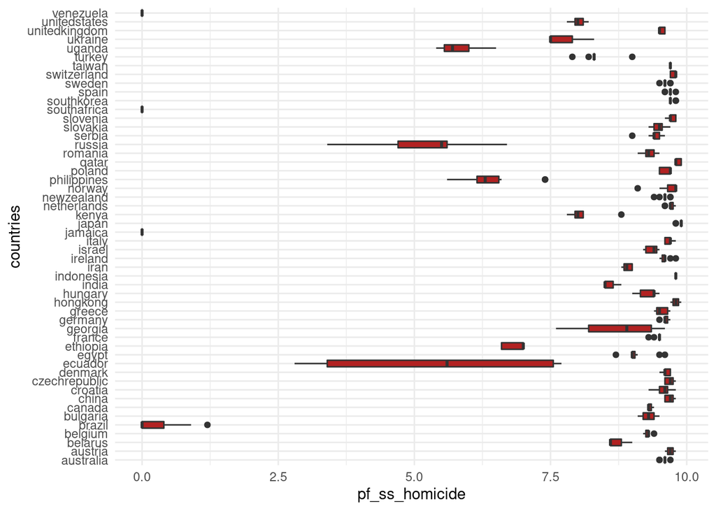

```r
ggplot(human_freedom) +
 aes(x = countries, y = pf_ss_homicide) +
 geom_boxplot(shape = "circle", fill = "#B22222") +
 coord_flip() +
 theme_minimal()#boxplot para visualizar a maior variação de pf_ss_homicide
```

```r
equador<-human_freedom%>%
  filter(countries== "ecuador")
diff(range(equador$pf_ss_homicide))#amplitude
```

```
## [1] 4.9
```